# Kelompok 3

# Packages

```r
library(spdep)        # Analisis data spasial: spatial autocorrelation, spatial regression
library(sp)           # Struktur data untuk manipulasi data spasial (poligon, titik, dll)
library(sf)           # Mengelola data spasial dengan standar Simple Features (sf)
library(readxl)       # Membaca file Excel (format .xls dan .xlsx)
library(openxlsx)     # Membuat, membaca, dan menulis file Excel (lebih cepat dari readxl)
```

```r
library(corrplot)     # Membuat visualisasi korelasi dalam bentuk plot
library(DescTools)    # Kumpulan fungsi statistik deskriptif dan inferensial
library(nortest)      # Melakukan uji normalitas (Anderson-Darling, Lilliefors, dll)
library(car)          # Fungsi regresi linear dan diagnostik model (vif, durbinWatsonTest, dll)
library(spatialreg)   # Estimasi model regresi spasial (SAR, SEM, SLM)
library(lmtest)       # Fungsi untuk menguji model regresi (heteroskedastisitas, serial correlation)
library(dplyr)        # Manipulasi data seperti filter, select, mutate, dan summarise
library(RColorBrewer) # Skema palet warna yang dapat digunakan dalam visualisasi
library(ggplot2)      # Membuat grafik statistik dengan pendekatan Grammar of Graphics
```

# Import Data

```r
library(readxl)

data_ipm <-read.xlsx("D:/Semester 5/Regspas/Projek UAS/Kemiskinan_pulau_sumatera.xlsx", sheet = "Sheet1")
str(data_ipm)
```

```
## 'data.frame':    154 obs. of  12 variables:
##  $ ID_PROV       : chr  "ID11" "ID11" "ID11" "ID11" ...
##  $ PROVINSI      : chr  "Aceh" "Aceh" "Aceh" "Aceh" ...
##  $ ID_KABKOT     : chr  "ID1101" "ID1102" "ID1103" "ID1104" ...
##  $ Kabupaten/Kota: chr  "Simeulue" "Aceh Singkil" "Aceh Selatan" "Aceh Tenggara" ...
##  $ Y             : num  17.9 19.1 12.1 12.4 13.4 ...
##  $ X1            : num  9.81 8.7 8.91 10.09 8.47 ...
##  $ X2            : num  5.85 6.84 4.73 5 8.03 4.42 6.07 8.17 5.92 4.14 ...
##  $ X3            : num  83.1 84 82.4 88 82.5 ...
##  $ X4            : num  72.7 67.9 74.5 65.1 70 ...
##  $ X5            : num  2.94 3.2 7.03 6.26 13.8 ...
##  $ longitude     : num  96.1 97.8 97.4 97.7 97.6 ...
##  $ latitude      : num  2.61 2.35 3.16 3.37 4.63 ...
```

```r
petaindo <- st_read("D:/Semester 5/Regspas/Projek UAS/idn_adm_bps_20200401_shp (1)/idn_admbnda_adm2_bps_20200401.shp")
str(petaindo)
```

```
## Classes 'sf' and 'data.frame':   522 obs. of  15 variables:
##  $ Shape_Leng: num  2.36 1.96 4.59 3.29 4.45 ...
##  $ Shape_Area: num  0.229 0.154 0.236 0.316 0.343 ...
##  $ ADM2_EN   : chr  "Aceh Barat" "Aceh Barat Daya" "Aceh Besar" "Aceh Jaya" ...
##  $ ADM2_PCODE: chr  "ID1107" "ID1112" "ID1108" "ID1116" ...
##  $ ADM2_REF  : chr  NA NA NA NA ...
##  $ ADM2ALT1EN: chr  NA NA NA NA ...
##  $ ADM2ALT2EN: chr  NA NA NA NA ...
##  $ ADM1_EN   : chr  "Aceh" "Aceh" "Aceh" "Aceh" ...
##  $ ADM1_PCODE: chr  "ID11" "ID11" "ID11" "ID11" ...
##  $ ADM0_EN   : chr  "Indonesia" "Indonesia" "Indonesia" "Indonesia" ...
##  $ ADM0_PCODE: chr  "ID" "ID" "ID" "ID" ...
##  $ date      : Date, format: "2019-12-20" "2019-12-20" ...
##  $ validOn   : Date, format: "2020-04-01" "2020-04-01" ...
##  $ validTo   : Date, format: "-001-11-30" "-001-11-30" ...
##  $ geometry  :sfc_MULTIPOLYGON of length 522; first list element: List of 1
##   ..$ :List of 1
##   .. ..$ : num [1:923, 1:2] 96.3 96.3 96.3 96.3 96.3 ...
##   ..- attr(*, "class")= chr [1:3] "XY" "MULTIPOLYGON" "sfg"
##  - attr(*, "sf_column")= chr "geometry"
##  - attr(*, "agr")= Factor w/ 3 levels "constant","aggregate",..: NA NA NA NA NA NA NA NA NA NA ...
##   ..- attr(*, "names")= chr [1:14] "Shape_Leng" "Shape_Area" "ADM2_EN" "ADM2_PCODE" ...
```

```r
library(dplyr)

petaindo_filtered <- petaindo %>%
  select(ADM2_EN, ADM2_PCODE, ADM1_EN, ADM1_PCODE, geometry)
```

```r
str(petaindo_filtered)
```

```
## Classes 'sf' and 'data.frame':   522 obs. of  5 variables:
##  $ ADM2_EN   : chr  "Aceh Barat" "Aceh Barat Daya" "Aceh Besar" "Aceh Jaya" ...
##  $ ADM2_PCODE: chr  "ID1107" "ID1112" "ID1108" "ID1116" ...
##  $ ADM1_EN   : chr  "Aceh" "Aceh" "Aceh" "Aceh" ...
##  $ ADM1_PCODE: chr  "ID11" "ID11" "ID11" "ID11" ...
##  $ geometry  :sfc_MULTIPOLYGON of length 522; first list element: List of 1
##   ..$ :List of 1
##   .. ..$ : num [1:923, 1:2] 96.3 96.3 96.3 96.3 96.3 ...
##   ..- attr(*, "class")= chr [1:3] "XY" "MULTIPOLYGON" "sfg"
##  - attr(*, "sf_column")= chr "geometry"
##  - attr(*, "agr")= Factor w/ 3 levels "constant","aggregate",..: NA NA NA NA
##   ..- attr(*, "names")= chr [1:4] "ADM2_EN" "ADM2_PCODE" "ADM1_EN" "ADM1_PCODE"
```

```r
# Filter kabupaten di SHP yang hanya ada di data Excel
shp_filtered <- petaindo_filtered %>%
  filter(ADM2_PCODE %in% data_ipm$ID_KABKOT)
str(shp_filtered)
```

```
## Classes 'sf' and 'data.frame':   154 obs. of  5 variables:
##  $ ADM2_EN   : chr  "Aceh Barat" "Aceh Barat Daya" "Aceh Besar" "Aceh Jaya" ...
##  $ ADM2_PCODE: chr  "ID1107" "ID1112" "ID1108" "ID1116" ...
##  $ ADM1_EN   : chr  "Aceh" "Aceh" "Aceh" "Aceh" ...
##  $ ADM1_PCODE: chr  "ID11" "ID11" "ID11" "ID11" ...
##  $ geometry  :sfc_MULTIPOLYGON of length 154; first list element: List of 1
##   ..$ :List of 1
##   .. ..$ : num [1:923, 1:2] 96.3 96.3 96.3 96.3 96.3 ...
##   ..- attr(*, "class")= chr [1:3] "XY" "MULTIPOLYGON" "sfg"
##  - attr(*, "sf_column")= chr "geometry"
##  - attr(*, "agr")= Factor w/ 3 levels "constant","aggregate",..: NA NA NA NA
##   ..- attr(*, "names")= chr [1:4] "ADM2_EN" "ADM2_PCODE" "ADM1_EN" "ADM1_PCODE"
```

```r
data_ipm <- data_ipm %>%
  rename(ADM2_PCODE = ID_KABKOT)
```

```r
sumatera <- shp_filtered %>%
  left_join(data_ipm, by = "ADM2_PCODE")
str(sumatera)
```

```
## Classes 'sf' and 'data.frame':   154 obs. of  16 variables:
##  $ ADM2_EN       : chr  "Aceh Barat" "Aceh Barat Daya" "Aceh Besar" "Aceh Jaya" ...
##  $ ADM2_PCODE    : chr  "ID1107" "ID1112" "ID1108" "ID1116" ...
##  $ ADM1_EN       : chr  "Aceh" "Aceh" "Aceh" "Aceh" ...
##  $ ADM1_PCODE    : chr  "ID11" "ID11" "ID11" "ID11" ...
##  $ ID_PROV       : chr  "ID11" "ID11" "ID11" "ID11" ...
##  $ PROVINSI      : chr  "Aceh" "Aceh" "Aceh" "Aceh" ...
##  $ Kabupaten/Kota: chr  "Aceh Barat" "Aceh Barat Daya" "Aceh Besar" "Aceh Jaya" ...
##  $ Y             : num  17.9 15.4 13.4 12.4 12.1 ...
##  $ X1            : num  9.98 8.77 10.36 8.74 8.91 ...
##  $ X2            : num  6.07 4.08 8.17 2.88 4.73 6.84 7.21 4.42 5 8.03 ...
##  $ X3            : num  97.1 92.7 92.6 87.9 82.4 ...
##  $ X4            : num  90.2 64.7 89.1 78.8 74.5 ...
##  $ X5            : num  13.57 4.96 16.98 3.37 7.03 ...
##  $ longitude     : num  96.2 96.9 95.5 95.7 97.4 ...
##  $ latitude      : num  4.46 3.82 5.38 4.83 3.16 ...
##  $ geometry      :sfc_MULTIPOLYGON of length 154; first list element: List of 1
##   ..$ :List of 1
##   .. ..$ : num [1:923, 1:2] 96.3 96.3 96.3 96.3 96.3 ...
##   ..- attr(*, "class")= chr [1:3] "XY" "MULTIPOLYGON" "sfg"
##  - attr(*, "sf_column")= chr "geometry"
##  - attr(*, "agr")= Factor w/ 3 levels "constant","aggregate",..: NA NA NA NA NA NA NA NA NA NA ...
##   ..- attr(*, "names")= chr [1:15] "ADM2_EN" "ADM2_PCODE" "ADM1_EN" "ADM1_PCODE" ...
```

```r
petasumatera <- sumatera %>%
  select(ADM2_EN, ADM2_PCODE, PROVINSI, ADM1_PCODE, geometry)
str(petasumatera)
```

```
## Classes 'sf' and 'data.frame':   154 obs. of  5 variables:
##  $ ADM2_EN   : chr  "Aceh Barat" "Aceh Barat Daya" "Aceh Besar" "Aceh Jaya" ...
##  $ ADM2_PCODE: chr  "ID1107" "ID1112" "ID1108" "ID1116" ...
##  $ PROVINSI  : chr  "Aceh" "Aceh" "Aceh" "Aceh" ...
##  $ ADM1_PCODE: chr  "ID11" "ID11" "ID11" "ID11" ...
##  $ geometry  :sfc_MULTIPOLYGON of length 154; first list element: List of 1
##   ..$ :List of 1
##   .. ..$ : num [1:923, 1:2] 96.3 96.3 96.3 96.3 96.3 ...
##   ..- attr(*, "class")= chr [1:3] "XY" "MULTIPOLYGON" "sfg"
##  - attr(*, "sf_column")= chr "geometry"
##  - attr(*, "agr")= Factor w/ 3 levels "constant","aggregate",..: NA NA NA NA
##   ..- attr(*, "names")= chr [1:4] "ADM2_EN" "ADM2_PCODE" "PROVINSI" "ADM1_PCODE"
```

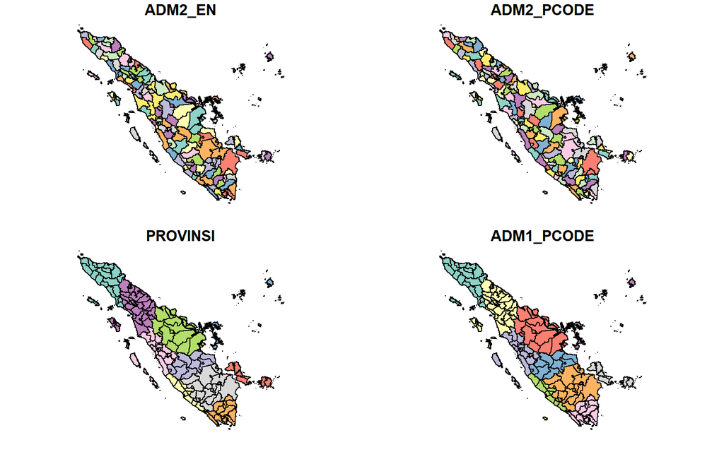

```r
plot(petasumatera, main = "Peta Pulau Sumatera")
```

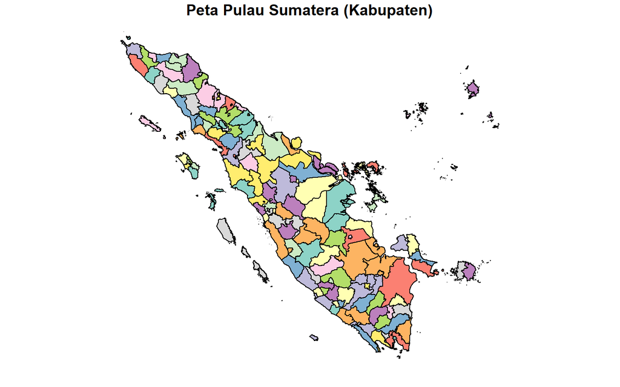

```r
plot(petasumatera[1], main = "Peta Pulau Sumatera (Kabupaten)")
```

# Eksplorasi Data

## Statistika Deskriptif

```r
summary(data_ipm[,-c(1,2)])
```

```
##   ADM2_PCODE        Kabupaten/Kota           Y                X1
##  Length:154         Length:154         Min.   : 2.270   Min.   : 6.140
##  Class :character   Class :character   1st Qu.: 6.812   1st Qu.: 8.133
##  Mode  :character   Mode  :character   Median : 9.110   Median : 8.810
##                                        Mean   :10.017   Mean   : 9.055
##                                        3rd Qu.:12.755   3rd Qu.: 9.920
##                                        Max.   :22.980   Max.   :13.040
##        X2               X3               X4              X5
##  Min.   : 0.450   Min.   : 28.96   Min.   :15.63   Min.   :  1.560
##  1st Qu.: 3.103   1st Qu.: 78.43   1st Qu.:70.55   1st Qu.:  7.881
##  Median : 4.420   Median : 87.00   Median :83.52   Median : 15.141
##  Mean   : 4.498   Mean   : 84.26   Mean   :78.83   Mean   : 29.345
##  3rd Qu.: 5.737   3rd Qu.: 93.67   3rd Qu.:91.05   3rd Qu.: 28.403
##  Max.   :10.860   Max.   :100.00   Max.   :99.91   Max.   :303.312
##    longitude         latitude
##  Min.   : 95.31   Min.   :-5.5327
##  1st Qu.: 98.85   1st Qu.:-2.8978
##  Median :101.28   Median :-0.2414
##  Mean   :101.28   Mean   :-0.1607
##  3rd Qu.:103.89   3rd Qu.: 2.5179
##  Max.   :108.26   Max.   : 5.8378
```

```r
# Menunjukkan kab/kota dengan Y tertinggi
kab_max <- data_ipm %>%
  arrange(desc(Y)) %>%
  slice(1)

print(paste("Kabupaten/kota dengan Y tertinggi adalah", kab_max$`Kabupaten/Kota`))
```

```
## [1] "Kabupaten/kota dengan Y tertinggi adalah Kepulauan Meranti"
```

```r
# Menunjukkan kab/kota dengan Y terendah
kab_min <- data_ipm %>%
  arrange(Y) %>%
  slice(1)

print(paste("Kabupaten/kota dengan Y terendah adalah", kab_min$`Kabupaten/Kota`))
```

```
## [1] "Kabupaten/kota dengan Y terendah adalah Kota Sawah Lunto"
```

## Boxplot - Identifikasi Pencilan

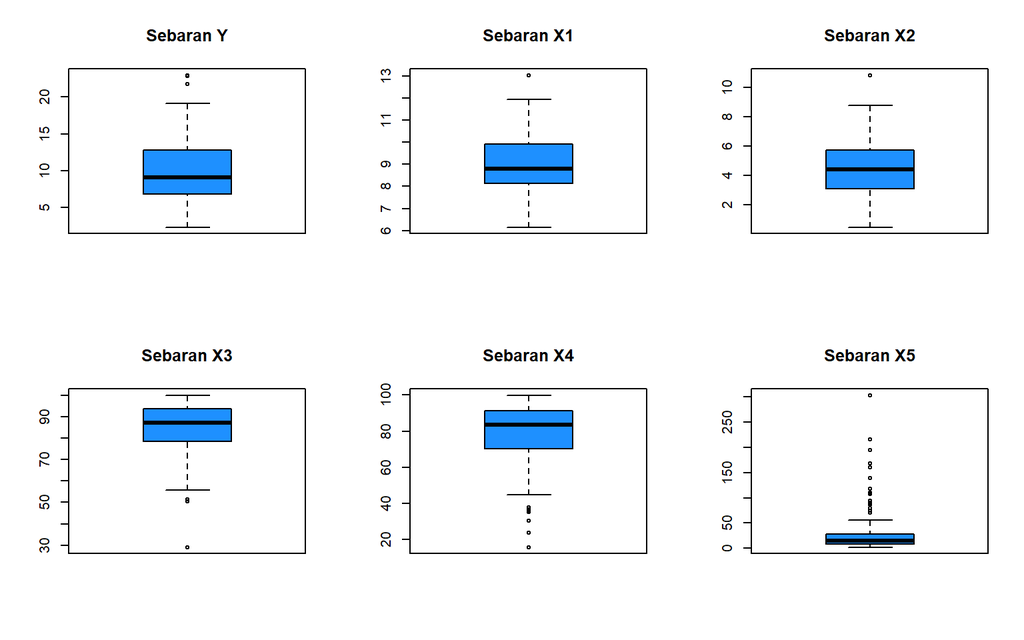

```r
par(mfrow=c(2,3))
boxplot(data_ipm$Y,main = "Sebaran Y", col="dodgerblue")
boxplot(data_ipm$X1,main = "Sebaran X1", col="dodgerblue")
boxplot(data_ipm$X2,main = "Sebaran X2", col="dodgerblue")
boxplot(data_ipm$X3,main = "Sebaran X3", col="dodgerblue")
boxplot(data_ipm$X4,main = "Sebaran X4", col="dodgerblue")
boxplot(data_ipm$X5,main = "Sebaran X5", col="dodgerblue")
```

Peubah PDRB memiliki banyak pencilan sehingga perlu dilakukan transformasi LOG

## Transformasi

```r
data_ipm$X5_log <- log(data_ipm$X5)
```

## Boxplot - Identifikasi Pencilan

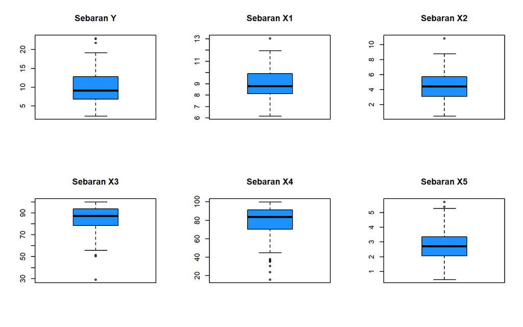

```r
par(mfrow=c(2,3))
boxplot(data_ipm$Y,main = "Sebaran Y", col="dodgerblue")
boxplot(data_ipm$X1,main = "Sebaran X1", col="dodgerblue")
boxplot(data_ipm$X2,main = "Sebaran X2", col="dodgerblue")
boxplot(data_ipm$X3,main = "Sebaran X3", col="dodgerblue")
boxplot(data_ipm$X4,main = "Sebaran X4", col="dodgerblue")
boxplot(data_ipm$X5_log,main = "Sebaran X5", col="dodgerblue")
```

## Hubungan antara Peubah Respon dan Peubah Penjelas

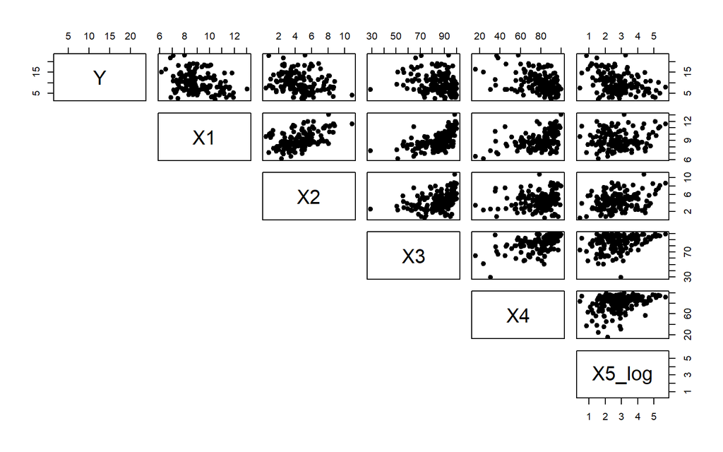

```r
pairs(data_ipm[,-c(1,2,3,4,10,11,12)], pch = 19, lower.panel = NULL)
```

## Korelasi antar Peubah

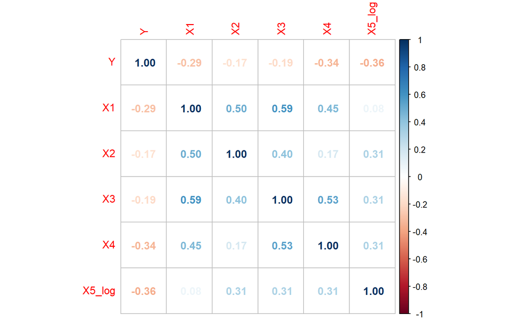

```r
corrplot(cor(data_ipm[,-c(1,2,3,4,10,11,12)]), method = "number")
```

### Uji Korelasi antarpeubah

#### Korelasi Y dengan X1

Ho: Tidak terdapat korelasi antara peubah Y dan X1

H1: Ada korelasi antara peubah Y dan X1

Keputusan: Tolak Ho jika p-value < alpha=0.05

```r
#Y dengan X1
cor.test(data_ipm$Y, data_ipm$X1)
```

```
##
##  Pearson's product-moment correlation
##
## data:  data_ipm$Y and data_ipm$X1
## t = -3.7516, df = 152, p-value = 0.0002494
## alternative hypothesis: true correlation is not equal to 0
## 95 percent confidence interval:
##  -0.4294974 -0.1393680
## sample estimates:
##        cor
## -0.2911118
```

Kesimpulan: Tolak Ho berarti pada taraf nyata 5% (p-value < 0.05), Terdapat korelasi antara peubah Y dan X1.

#### Korelasi Y dengan X2

Ho: Tidak terdapat korelasi antara peubah Y dan X2

H1: Ada korelasi antara peubah Y dan X2

Keputusan: Tolak Ho jika p-value < alpha=0.05

```r
#Y dengan X2
cor.test(data_ipm$Y, data_ipm$X2)
```

```
##
##  Pearson's product-moment correlation
##
## data:  data_ipm$Y and data_ipm$X2
## t = -2.1036, df = 152, p-value = 0.03706
## alternative hypothesis: true correlation is not equal to 0
## 95 percent confidence interval:
##  -0.31790024 -0.01030997
## sample estimates:
##        cor
## -0.1681964
```

Kesimpulan: Tolak Ho berarti pada taraf nyata 5% (p-value < 0.05), Terdapat korelasi antara peubah Y dan X2.

#### Korelasi Y dengan X3

Ho: Tidak terdapat korelasi antara peubah Y dan X3

H1: Ada korelasi antara peubah Y dan X3

Keputusan: Tolak Ho jika p-value < alpha=0.05

```r
#Y dengan X3
cor.test(data_ipm$Y, data_ipm$X3)
```

```
##
##  Pearson's product-moment correlation
##
## data:  data_ipm$Y and data_ipm$X3
## t = -2.4019, df = 152, p-value = 0.01752
## alternative hypothesis: true correlation is not equal to 0
## 95 percent confidence interval:
##  -0.33912953 -0.03409617
## sample estimates:
##        cor
## -0.1912256
```

Kesimpulan: Tolak Ho berarti pada taraf nyata 5% (p-value < 0.05), Terdapat korelasi antara peubah Y dan X3.

#### Korelasi Y dengan X4

Ho: Tidak terdapat korelasi antara peubah Y dan X4

H1: Ada korelasi antara peubah Y dan X4

Keputusan: Tolak Ho jika p-value < alpha=0.05

```r
#Y dengan X4
cor.test(data_ipm$Y, data_ipm$X4)
```

```
##
##  Pearson's product-moment correlation
##
## data:  data_ipm$Y and data_ipm$X4
## t = -4.4217, df = 152, p-value = 1.855e-05
## alternative hypothesis: true correlation is not equal to 0
## 95 percent confidence interval:
##  -0.4706253 -0.1895535
## sample estimates:
##        cor
## -0.3375932
```

Kesimpulan: Tolak Ho berarti pada taraf nyata 5% (p-value < 0.05), Terdapat korelasi antara peubah Y dan X4.

#### Korelasi Y dengan X5

Ho: Tidak terdapat korelasi antara peubah Y dan X5

H1: Ada korelasi antara peubah Y dan X5

Keputusan: Tolak Ho jika p-value < alpha=0.05

```r
#Y dengan X5
cor.test(data_ipm$Y, data_ipm$X5_log)
```

```
##
##  Pearson's product-moment correlation
##
## data:  data_ipm$Y and data_ipm$X5_log
## t = -4.8332, df = 152, p-value = 3.257e-06
## alternative hypothesis: true correlation is not equal to 0
## 95 percent confidence interval:
##  -0.4945892 -0.2194882
## sample estimates:
##        cor
## -0.3649789
```

Kesimpulan: Tolak Ho berarti pada taraf nyata 5% (p-value < 0.05), Terdapat korelasi antara peubah Y dan X5.

## Sebaran Spasial Data

### Sebaran Peubah Y

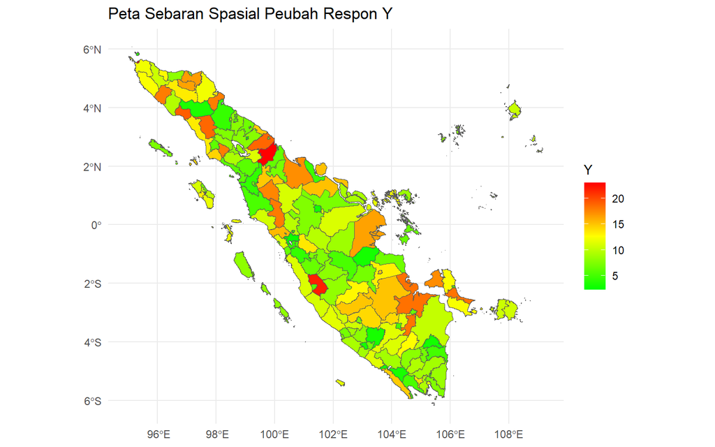

```r
k=101
colfunc <- colorRampPalette(c("green", "yellow","red"))

petasumatera$Y <- data_ipm$Y

# Plot menggunakan ggplot2
ggplot(petasumatera) +
  geom_sf(aes(fill = Y)) +
  scale_fill_gradientn(colors = colfunc(k)) +
  labs(title = "Peta Sebaran Spasial Peubah Respon Y") +
  theme_minimal()
```

Berdasarkan plot di atas, dapat dilihat adanya kecenderungan pola bergerombol dengan wilayah tetangganya pada kemiskinan di pulau sumatera. Hal ini tampak dari gradasi warna yang cenderung mengumpul. Artinya terdapat kemiripan antar kabupaten/kota terhadap sebaran presentase kemiskinan sehingga terindikasi adanya autokorelasi spasial positif. Selain itu, Berdasarkan Plot tersebut juga terlihat bahwa tingkat kemiskinan pada kabupaten/kota di pulau sumatera cenderung rendah, dengan terdapat beberapa hotspot atau daerah yang memiliki tingkat kemiskinan yang tinggi.

### Sebaran Peubah X1

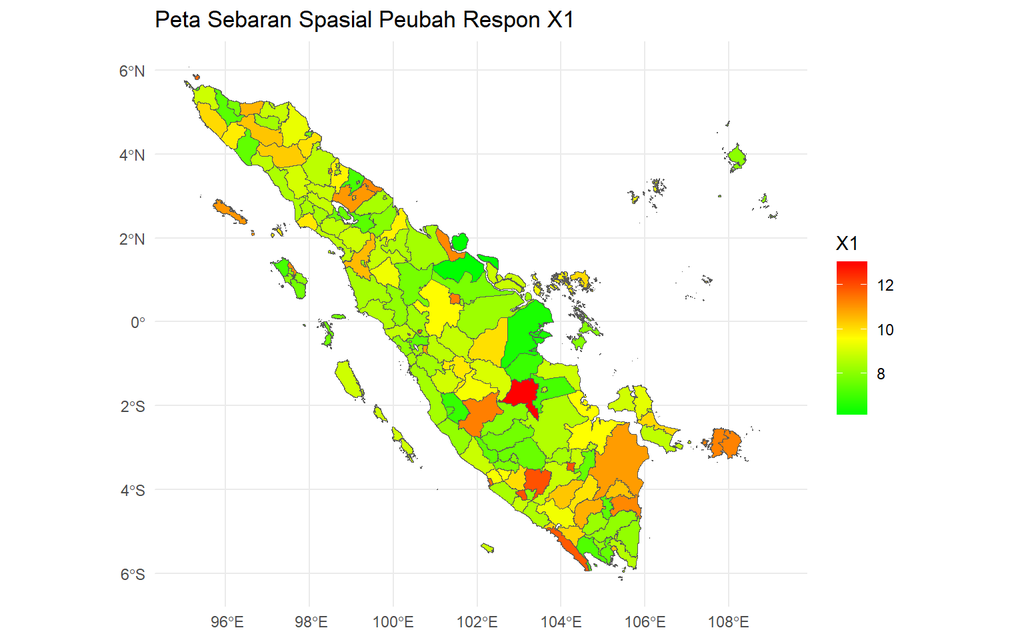

```r
k=101
colfunc <- colorRampPalette(c("green", "yellow","red"))

petasumatera$X1 <- data_ipm$X1

# Plot menggunakan ggplot2
ggplot(petasumatera) +
  geom_sf(aes(fill = X1)) +
  scale_fill_gradientn(colors = colfunc(k)) +
  labs(title = "Peta Sebaran Spasial Peubah Respon X1") +
  theme_minimal()
```

### Sebaran Peubah X2

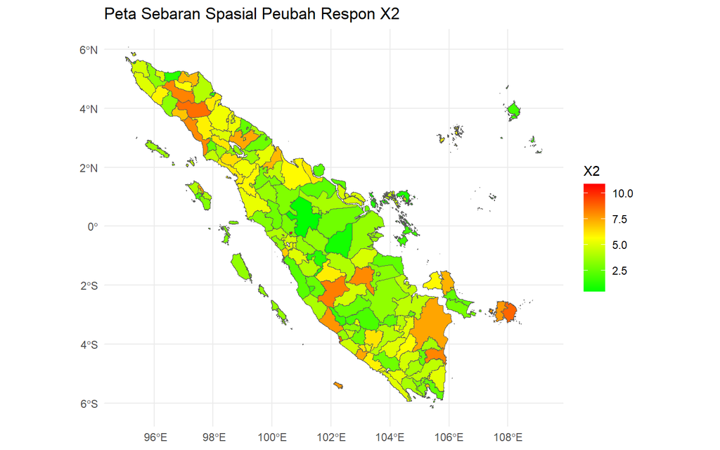

```r
k=101
colfunc <- colorRampPalette(c("green", "yellow","red"))

petasumatera$X2 <- data_ipm$X2

# Plot menggunakan ggplot2
ggplot(petasumatera) +
  geom_sf(aes(fill = X2)) +
  scale_fill_gradientn(colors = colfunc(k)) +
  labs(title = "Peta Sebaran Spasial Peubah Respon X2") +
  theme_minimal()
```

### Sebaran Peubah X3

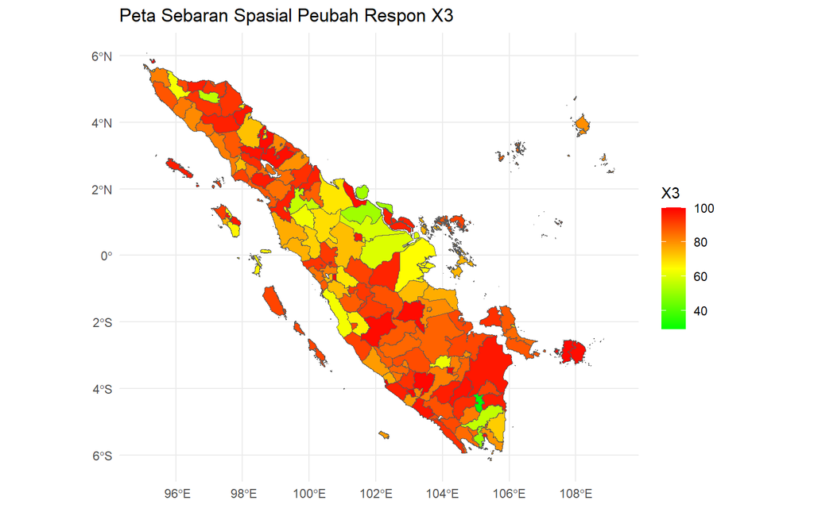

```r
k=101
colfunc <- colorRampPalette(c("green", "yellow","red"))

petasumatera$X3 <- data_ipm$X3

# Plot menggunakan ggplot2
ggplot(petasumatera) +
  geom_sf(aes(fill = X3)) +
  scale_fill_gradientn(colors = colfunc(k)) +
  labs(title = "Peta Sebaran Spasial Peubah Respon X3") +
  theme_minimal()
```

### Sebaran Peubah X4

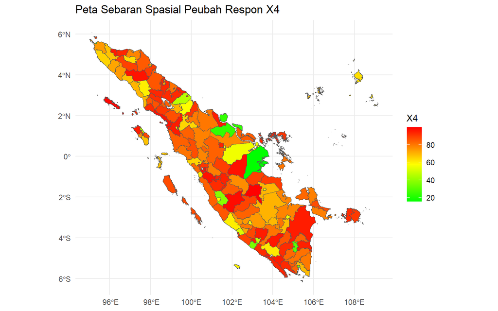

```r
k=101
colfunc <- colorRampPalette(c("green", "yellow","red"))

petasumatera$X4 <- data_ipm$X4

# Plot menggunakan ggplot2
ggplot(petasumatera) +
  geom_sf(aes(fill = X4)) +
  scale_fill_gradientn(colors = colfunc(k)) +
  labs(title = "Peta Sebaran Spasial Peubah Respon X4") +
  theme_minimal()
```

### Sebaran Peubah X5

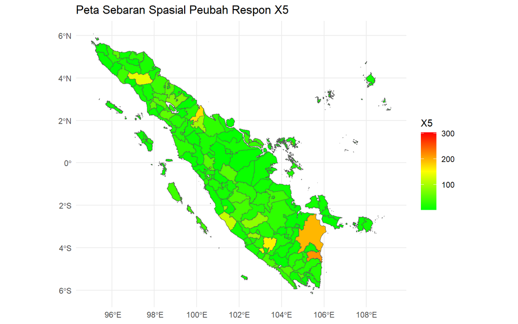

```r
k=101
colfunc <- colorRampPalette(c("green", "yellow","red"))

petasumatera$X5 <- data_ipm$X5

# Plot menggunakan ggplot2
ggplot(petasumatera) +
  geom_sf(aes(fill = X5)) +
  scale_fill_gradientn(colors = colfunc(k)) +
  labs(title = "Peta Sebaran Spasial Peubah Respon X5") +
  theme_minimal()
```

# Matriks Pembobot Spasial

## Matriks Bobot Berdasarkan Ketetanggan

### Queen Contiguity

```r
# Memvalidasi geometri dalam objek sf
peta <- st_make_valid(petasumatera)
# Konversi objek sf ke objek sp
sp.peta <- as(peta, "Spatial")

# Mengakses slot polygons dari objek sp
sp.polygons <- SpatialPolygons(sp.peta@polygons)
queen <- poly2nb(sp.peta, queen = T)
```

```r
queen
```

```
## Neighbour list object:
## Number of regions: 154
## Number of nonzero links: 636
## Percentage nonzero weights: 2.681734
## Average number of links: 4.12987
## 8 regions with no links:
## 40 44 45 46 50 73 106 140
## 13 disjoint connected subgraphs
```

```r
W.queen <- nb2listw(queen, style='W',zero.policy=TRUE)
qc = moran.test(data_ipm$Y, W.queen,randomisation=T,
alternative="greater", zero.policy = TRUE)
qc
```

```
##
##  Moran I test under randomisation
##
## data:  data_ipm$Y
## weights: W.queen
## n reduced by no-neighbour observations
##
## Moran I statistic standard deviate = 1.0341, p-value = 0.1505
## alternative hypothesis: greater
## sample estimates:
## Moran I statistic       Expectation          Variance
##       0.058054149      -0.006896552       0.003944859
```

```r
moran.mc(data_ipm$Y, listw = W.queen, zero.policy = TRUE, nsim = 99)
```

```
##
##  Monte-Carlo simulation of Moran I
##
## data:  data_ipm$Y
## weights: W.queen
## number of simulations + 1: 100
##
## statistic = 0.058054, observed rank = 86, p-value = 0.14
## alternative hypothesis: greater
```

### Rook Contiguity

```r
rook <- poly2nb(sp.peta, queen = F)
```

```r
rook
```

```
## Neighbour list object:
## Number of regions: 154
## Number of nonzero links: 632
## Percentage nonzero weights: 2.664868
## Average number of links: 4.103896
## 8 regions with no links:
## 40 44 45 46 50 73 106 140
## 13 disjoint connected subgraphs
```

```r
W.rook <- nb2listw(rook, style='W',zero.policy=TRUE)
rc = moran.test(data_ipm$Y, W.rook,randomisation=T,
alternative="greater", zero.policy = TRUE)
rc
```

```
##
##  Moran I test under randomisation
##
## data:  data_ipm$Y
## weights: W.rook
## n reduced by no-neighbour observations
##
## Moran I statistic standard deviate = 0.99931, p-value = 0.1588
## alternative hypothesis: greater
## sample estimates:
## Moran I statistic       Expectation          Variance
##       0.056033246      -0.006896552       0.003965600
```

## Matriks Bobot Berdasarkan Jarak

```r
# Menghitung centroid dari setiap unit spasial
centroids <- st_centroid(peta)
# Ekstrak koordinat centroid
longlat <- st_coordinates(centroids)

# Tambahkan koordinat long dan lat ke objek peta
peta$long <- longlat[, 1]  # Kolom X (long)
peta$lat  <- longlat[, 2]  # Kolom Y (lat)
```

```r
coords <- peta[c("long","lat")]
#class(coords)
koord <- as.data.frame(coords)
jarak<-dist(longlat, method = "euclidean")
m.jarak<-as.matrix(jarak)
```

### K-Nearest Neighbor

```r
# k = 10
W.knn<-knn2nb(knearneigh(longlat,k=10,longlat=TRUE))
W.knn.s <- nb2listw(W.knn,style='W')

MI.knn <- moran(data_ipm$Y,W.knn.s,n=length(W.knn.s$neighbours),S0=Szero(W.knn.s))
mt1 = moran.test(data_ipm$Y,W.knn.s,randomisation = T,alternative = "greater")
mt1
```

```
##
##  Moran I test under randomisation
##
## data:  data_ipm$Y
## weights: W.knn.s
##
## Moran I statistic standard deviate = 2.3549, p-value = 0.009263
## alternative hypothesis: greater
## sample estimates:
## Moran I statistic       Expectation          Variance
##       0.070153337      -0.006535948       0.001060503
```

### Radial Distance Weight

```r
W.rdw <-dnearneigh(longlat,0,300,longlat=TRUE)
W.rdw.s <- nb2listw(W.rdw,style='W')

MI.rdw <- moran(data_ipm$Y,W.rdw.s,n=length(W.rdw.s$neighbours),S0=Szero(W.rdw.s))
mt2 = moran.test(data_ipm$Y,W.rdw.s,randomisation = T,alternative = "greater")
mt2
```

```
##
##  Moran I test under randomisation
##
## data:  data_ipm$Y
## weights: W.rdw.s
##
## Moran I statistic standard deviate = 0.99182, p-value = 0.1606
## alternative hypothesis: greater
## sample estimates:
## Moran I statistic       Expectation          Variance
##      0.0122645740     -0.0065359477      0.0003593156
```

### Invers Distance Weight

```r
alpha1=1
W.idw <-1/(m.jarak^alpha1)
diag(W.idw)<-0
rtot<-rowSums(W.idw,na.rm=TRUE)
W.idw.sd<-W.idw/rtot #row-normalized
W.idw.s = mat2listw(W.idw.sd,style='W')

MI.idw <- moran(data_ipm$Y,W.idw.s,n=length(W.idw.s$neighbours),S0=Szero(W.idw.s))
mt3 = moran.test(data_ipm$Y,W.idw.s,randomisation = T,alternative = "greater")
mt3
```

```
##
##  Moran I test under randomisation
##
## data:  data_ipm$Y
## weights: W.idw.s
##
## Moran I statistic standard deviate = 1.4749, p-value = 0.07011
## alternative hypothesis: greater
## sample estimates:
## Moran I statistic       Expectation          Variance
##      0.0118527394     -0.0065359477      0.0001554352
```

```r
alpha2=2
W.idw2<-1/(m.jarak^alpha2)
diag(W.idw2)<-0
rtot<-rowSums(W.idw2,na.rm=TRUE)
W.idw2.sd<-W.idw2/rtot #row-normalized
W.idw2.s = mat2listw(W.idw2.sd,style='W')

MI.idw2 <- moran(data_ipm$Y,W.idw2.s,n=length(W.idw2.s$neighbours),S0=Szero(W.idw2.s))
mt4 = moran.test(data_ipm$Y,W.idw2.s,randomisation = T,alternative = "greater")
mt4
```

```
##
##  Moran I test under randomisation
##
## data:  data_ipm$Y
## weights: W.idw2.s
##
## Moran I statistic standard deviate = 0.79595, p-value = 0.213
## alternative hypothesis: greater
## sample estimates:
## Moran I statistic       Expectation          Variance
##       0.025124731      -0.006535948       0.001582230
```

## Exponential Distance Weight

```r
alpha=1
W.edw<-exp((-alpha)*m.jarak)
diag(W.edw)<-0
rtot<-rowSums(W.edw,na.rm=TRUE)
W.edw.sd<-W.edw/rtot #row-normalized
W.edw.s = mat2listw(W.edw.sd,style='W')

MI.edw <- moran(data_ipm$Y,W.edw.s,n=length(W.edw.s$neighbours),S0=Szero(W.edw.s))
mt5 = moran.test(data_ipm$Y,W.edw.s,randomisation = T,alternative = "greater")
mt5
```

```
##
##  Moran I test under randomisation
##
## data:  data_ipm$Y
## weights: W.edw.s
##
## Moran I statistic standard deviate = 1.1301, p-value = 0.1292
## alternative hypothesis: greater
## sample estimates:
## Moran I statistic       Expectation          Variance
##      0.0145480678     -0.0065359477      0.0003480746
```

```r
alpha=2
W.edw<-exp((-alpha)*m.jarak)
diag(W.edw)<-0
rtot<-rowSums(W.edw,na.rm=TRUE)
W.edw.sd<-W.edw/rtot #row-normalized
W.edw.s = mat2listw(W.edw.sd,style='W')

MI.edw2 <- moran(data_ipm$Y,W.edw.s,n=length(W.edw.s$neighbours),S0=Szero(W.edw.s))
mt6 = moran.test(data_ipm$Y,W.edw.s,randomisation = T,alternative = "greater")
mt6
```

```
##
##  Moran I test under randomisation
##
## data:  data_ipm$Y
## weights: W.edw.s
##
## Moran I statistic standard deviate = 0.67322, p-value = 0.2504
## alternative hypothesis: greater
## sample estimates:
## Moran I statistic       Expectation          Variance
##       0.015366071      -0.006535948       0.001058396
```

## Pemilihan Matriks Bobot Terbaik

```r
MatriksBobot <- c("K-Nearest Neighbor (k=10)",
                  "Radial Distance Weight (dmax=300)",
                  "Invers Distance Weight (alpha=1)",
                  "Invers Distance Weight (alpha=2)",
                  "Exponential Distance Weight (alpha=1)",
                  "Exponential Distance Weight (alpha=2)",
                  "Rook Contiguity",
                  "Queen Contiguity")
IndeksMoran <- c(MI.knn$I,MI.rdw$I,MI.idw$I,MI.idw2$I,MI.edw$I,MI.edw2$I,rc$estimate[1],qc$estimate[1])
pv = c(mt1$p.value,mt2$p.value,mt3$p.value,mt4$p.value,mt5$p.value,mt6$p.value,rc$p.value,qc$p.value)
Matriks = cbind.data.frame(MatriksBobot, IndeksMoran,"p-value"=pv)
colnames(Matriks) <-c("Matriks Bobot", "Indeks Moran", "p-value")
Matriks
```

```
##                           Matriks Bobot Indeks Moran     p-value
## 1             K-Nearest Neighbor (k=10)   0.07015334 0.009263006
## 2     Radial Distance Weight (dmax=300)   0.01226457 0.160643224
## 3      Invers Distance Weight (alpha=1)   0.01185274 0.070113580
## 4      Invers Distance Weight (alpha=2)   0.02512473 0.213030750
## 5 Exponential Distance Weight (alpha=1)   0.01454807 0.129216905
## 6 Exponential Distance Weight (alpha=2)   0.01536607 0.250402209
## 7                       Rook Contiguity   0.05603325 0.158821336
## 8                      Queen Contiguity   0.05805415 0.150541620
```

Berdasakan hasil di atas, Matriks bobot yang memiliki nilai Indeks Moran yang signifikan pada taraf 5% adalah k-nearest neighbor (k=10).Selain itu, matriks ini juga memiliki Indeks Moran tertinggi sehingga matriks tersebut dapat dipilih menjadi matriks pembobot spasial yang terbaik diantara matriks pembobot lainnya. Selanjutnya matriks pembobot yang digunakan dalam analisis adalah k-nearest neighbor dengan 10 tetangga terdekat.

# Model Regresi Klasik (OLS)

## Metode OLS

```r
ols <- lm(Y~X1+X2+X3+X4+X5_log, data=data_ipm)
summary(ols)
```

```
##
## Call:
## lm(formula = Y ~ X1 + X2 + X3 + X4 + X5_log, data = data_ipm)
##
## Residuals:
##     Min      1Q  Median      3Q     Max
## -8.5884 -3.0538 -0.3559  2.1941 10.6730
##
## Coefficients:
##             Estimate Std. Error t value Pr(>|t|)
## (Intercept) 22.13098    2.61195   8.473 2.21e-14 ***
## X1          -1.08137    0.34867  -3.101  0.00231 **
## X2           0.13901    0.20585   0.675  0.50053
## X3           0.06700    0.03580   1.872  0.06323 .
## X4          -0.05336    0.02509  -2.126  0.03513 *
## X5_log      -1.56691    0.36247  -4.323 2.81e-05 ***
## ---
## Signif. codes:  0 '***' 0.001 '**' 0.01 '*' 0.05 '.' 0.1 ' ' 1
##
## Residual standard error: 3.984 on 148 degrees of freedom
## Multiple R-squared:  0.2417, Adjusted R-squared:  0.216
## F-statistic: 9.432 on 5 and 148 DF,  p-value: 8.001e-08
```

## Diagnostik Model

### Uji Normalitas Sisaan

```r
err.ols <- residuals(ols)
ad.test(err.ols)
```

```
##
##  Anderson-Darling normality test
##
## data:  err.ols
## A = 0.61853, p-value = 0.1056
```

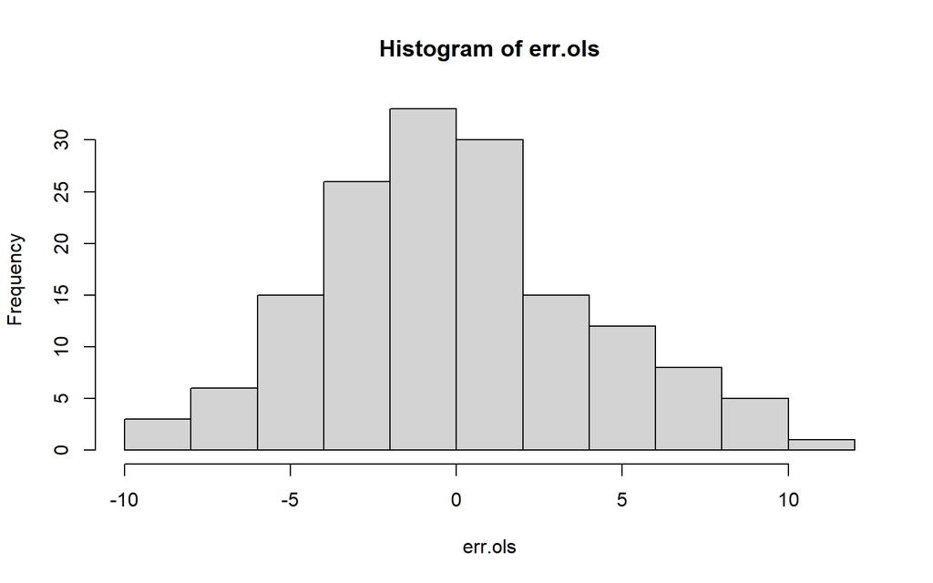

```r
hist(err.ols)
```

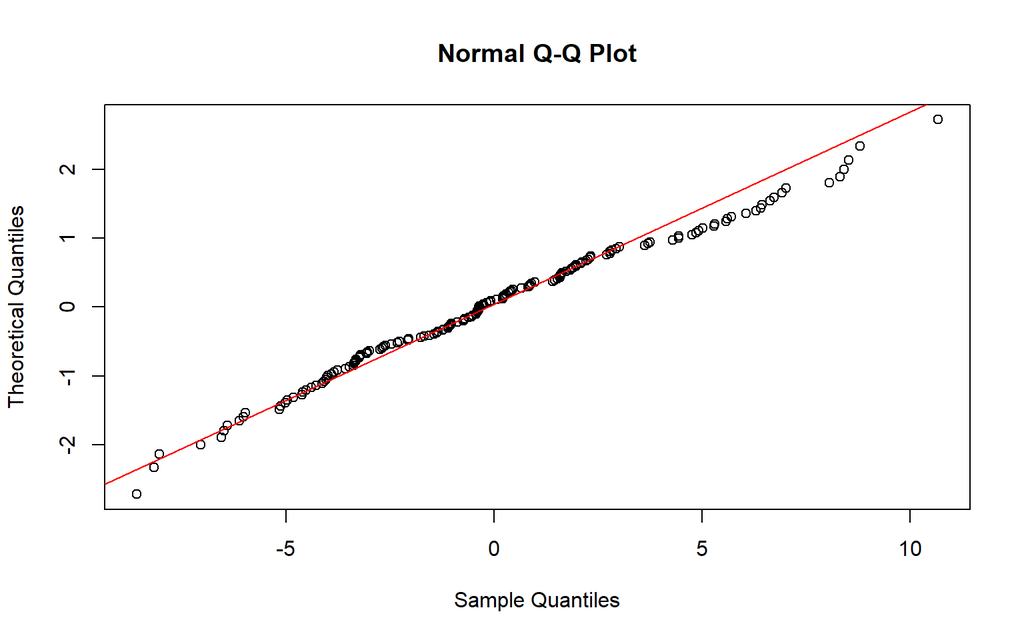

```r
qqnorm(err.ols,datax=T)
qqline(rnorm(length(err.ols),mean(err.ols),sd(err.ols)),datax=T, col="red")
```

### Uji Kehomogenan Ragam

H0 : Ragam Sisaan Homogen H1 : Ragam Sisaan Tidak Homogen

```r
lmtest::bptest(ols)
```

```
##
##  studentized Breusch-Pagan test
##
## data:  ols
## BP = 6.3762, df = 5, p-value = 0.2713
```

Karena p-value > 0.05, maka gagal tolak H0. Artinya ragam sisaan homogen

### Uji Multikolinearitas

```r
car::vif(ols)
```

```
##       X1       X2       X3       X4   X5_log
## 2.038188 1.554655 1.920589 1.593923 1.328109
```

Berdasarkan perhitungan, diperoleh nilai VIF < 5 yang menunjukkan tidak terjadi multikolinearitas antar peubah penjelas.

```r
aic_value <- AIC(ols)
print(aic_value)
```

```
## [1] 870.6665
```

# Pengujian Efek Spasial

## Efek Dependensi Spasial

### Uji Indeks Moran

H0 : Tidak ada autokorelasi spasial

H1 : Ada autokorelasi spasial

Uji Indeks Moran pada Galat Model Regresi

```r
ww = W.knn.s
lm.morantest(ols, listw=ww, alternative="two.sided", zero.policy = TRUE)
```

```
##
##  Global Moran I for regression residuals
##
## data:
## model: lm(formula = Y ~ X1 + X2 + X3 + X4 + X5_log, data = data_ipm)
## weights: ww
##
## Moran I statistic standard deviate = 2.2133, p-value = 0.02688
## alternative hypothesis: two.sided
## sample estimates:
## Observed Moran I      Expectation         Variance
##      0.064440301     -0.007310476      0.001050903
```

```r
err.ols <- residuals(ols)
merr <- moran.test(err.ols, ww,randomisation=T,
           alternative="two.sided")
merr
```

```
##
##  Moran I test under randomisation
##
## data:  err.ols
## weights: ww
##
## Moran I statistic standard deviate = 2.1783, p-value = 0.02938
## alternative hypothesis: two.sided
## sample estimates:
## Moran I statistic       Expectation          Variance
##       0.064440301      -0.006535948       0.001061686
```

Uji Indeks Moran pada Peubah Y

```r
my <- moran.test(data_ipm$Y, ww,randomisation=T,
           alternative="two.sided")
my
```

```
##
##  Moran I test under randomisation
##
## data:  data_ipm$Y
## weights: ww
##
## Moran I statistic standard deviate = 2.3549, p-value = 0.01853
## alternative hypothesis: two.sided
## sample estimates:
## Moran I statistic       Expectation          Variance
##       0.070153337      -0.006535948       0.001060503
```

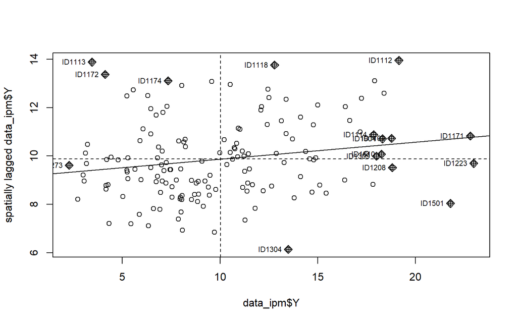

```r
moran.plot(data_ipm$Y, ww, labels=sumatera$ADM2_PCODE)
```

Uji Indeks Moran pada Peubah X1

```r
mx1 <- moran.test(data_ipm$X1, ww,randomisation=T,
           alternative="two.sided")
mx1
```

```
##
##  Moran I test under randomisation
##
## data:  data_ipm$X1
## weights: ww
##
## Moran I statistic standard deviate = -0.59664, p-value = 0.5507
## alternative hypothesis: two.sided
## sample estimates:
## Moran I statistic       Expectation          Variance
##      -0.025974264      -0.006535948       0.001061441
```

Uji Indeks Moran pada Peubah X2

```r
mx2 <- moran.test(data_ipm$X2, ww,randomisation=T,
           alternative="two.sided")
mx2
```

```
##
##  Moran I test under randomisation
##
## data:  data_ipm$X2
## weights: ww
##
## Moran I statistic standard deviate = 1.6895, p-value = 0.09112
## alternative hypothesis: two.sided
## sample estimates:
## Moran I statistic       Expectation          Variance
##       0.048470121      -0.006535948       0.001059977
```

Uji Indeks Moran pada Peubah X3

```r
mx3 <- moran.test(data_ipm$X3, ww,randomisation=T,
           alternative="two.sided")
mx3
```

```
##
##  Moran I test under randomisation
##
## data:  data_ipm$X3
## weights: ww
##
## Moran I statistic standard deviate = 1.1574, p-value = 0.2471
## alternative hypothesis: two.sided
## sample estimates:
## Moran I statistic       Expectation          Variance
##       0.030910607      -0.006535948       0.001046826
```

Uji Indeks Moran pada Peubah X4

```r
mx4 <- moran.test(data_ipm$X4, ww,randomisation=T,
           alternative="two.sided")
mx4
```

```
##
##  Moran I test under randomisation
##
## data:  data_ipm$X4
## weights: ww
##
## Moran I statistic standard deviate = -0.20253, p-value = 0.8395
## alternative hypothesis: two.sided
## sample estimates:
## Moran I statistic       Expectation          Variance
##      -0.013083818      -0.006535948       0.001045233
```

Uji Indeks Moran pada Peubah X5

```r
mx5 <- moran.test(data_ipm$X5_log, ww,randomisation=T,
           alternative="two.sided")
mx5
```

```
##
##  Moran I test under randomisation
##
## data:  data_ipm$X5_log
## weights: ww
##
## Moran I statistic standard deviate = 0.43469, p-value = 0.6638
## alternative hypothesis: two.sided
## sample estimates:
## Moran I statistic       Expectation          Variance
##       0.007614155      -0.006535948       0.001059649
```

Berikut ini adalah hasil uji autokorelasi pada peubah respon, peubah penjelas, dan sisaan regresi

```r
Peubah = c("Y","X1","X2","X3","X4","X5","Sisaan")
Indeks_Moran = c(my$estimate[1], mx1$estimate[1], mx2$estimate[1],  mx3$estimate[1],  mx4$estimate[1],  mx5$estimate[1], merr$estimate[1])
p_value = c(my$p.value, mx1$p.value, mx2$p.value,mx3$p.value, mx4$p.value, mx5$p.value, merr$p.value)

df1 = cbind.data.frame(Peubah, Indeks_Moran, p_value)
colnames(df1) <- c("Peubah", "Indeks Moran", "p-value")
df1
```

```
##   Peubah Indeks Moran    p-value
## 1      Y  0.070153337 0.01852601
## 2     X1 -0.025974264 0.55074929
## 3     X2  0.048470121 0.09112052
## 4     X3  0.030910607 0.24711868
## 5     X4 -0.013083818 0.83950085
## 6     X5  0.007614155 0.66378823
## 7 Sisaan  0.064440301 0.02938474
```

Berdasarkan hasil pengujian Indeks Moran di atas menunjukkan bahwa nilai indeks Moran pada peubah Y dan sisaan model regresi memiliki nilai p-value < 0.05 maka Tolak H0 sehingga autokorelasi spasial pada peubah tersebut berpengaruh nyata. Hal ini mengindikasikan bahwa terdapat ketergantungan spasial pada peubah y dan sisaan model regresi klasik. Terlihat pula nilai indeks moran positif pada peubah Y dan sisaan model regresi klasik yang menunjukkan adanya autokorelasi positif.

Sedangkan, nilai indeks moran pada peubah penjelas memiliki p-value > 0.05 maka gagal tolak H0 artinya tidak terdapat autokorelasi spasial peubah penjelas taraf nyata 5%.

Oleh karenanya, untuk mencari model yang lebih baik, kita dapat melakukan uji LM (lagrange multiplier) untuk mengidentifikasi model dependensi spasial yang dapat digunakan pada kasus ini.

### Uji Lagrange Multiplier

```r
model <- lm.LMtests(ols,listw=ww,zero.policy = TRUE, test=c("LMerr","RLMerr","LMlag","RLMlag","SARMA"))
```

```
## Please update scripts to use lm.RStests in place of lm.LMtests
```

```r
summary(model)
```

```
##  Rao's score (a.k.a Lagrange multiplier) diagnostics for spatial
##  dependence
## data:
## model: lm(formula = Y ~ X1 + X2 + X3 + X4 + X5_log, data = data_ipm)
## test weights: listw
##
##          statistic parameter p.value
## RSerr      3.61269         1 0.05734 .
## adjRSerr   0.84286         1 0.35858
## RSlag      5.25407         1 0.02190 *
## adjRSlag   2.48425         1 0.11499
## SARMA      6.09694         2 0.04743 *
## ---
## Signif. codes:  0 '***' 0.001 '**' 0.01 '*' 0.05 '.' 0.1 ' ' 1
```

# Model Regresi Spasial

## Model SAR

```r
sar <- lagsarlm(Y ~ X1 + X2 + X3 + X4 + X5_log, data = data_ipm, listw = ww)
summary(sar, Nagelkerke = T)
```

```
##
## Call:lagsarlm(formula = Y ~ X1 + X2 + X3 + X4 + X5_log, data = data_ipm,
##     listw = ww)
##
## Residuals:
##      Min       1Q   Median       3Q      Max
## -8.58696 -2.97066 -0.19429  2.33521 10.73820
##
## Type: lag
## Coefficients: (asymptotic standard errors)
##              Estimate Std. Error z value  Pr(>|z|)
## (Intercept) 19.045154   2.862361  6.6537 2.859e-11
## X1          -1.060725   0.336064 -3.1563  0.001598
## X2           0.099839   0.198296  0.5035  0.614623
## X3           0.065360   0.034476  1.8958  0.057985
## X4          -0.054441   0.024165 -2.2528  0.024270
## X5_log      -1.496211   0.349091 -4.2860 1.819e-05
##
## Rho: 0.31412, LR test value: 4.1165, p-value: 0.042468
## Asymptotic standard error: 0.14476
##     z-value: 2.1699, p-value: 0.030014
## Wald statistic: 4.7085, p-value: 0.030014
##
## Log likelihood: -426.275 for lag model
## ML residual variance (sigma squared): 14.722, (sigma: 3.8369)
## Nagelkerke pseudo-R-squared: 0.26165
## Number of observations: 154
## Number of parameters estimated: 8
## AIC: 868.55, (AIC for lm: 870.67)
## LM test for residual autocorrelation
## test value: 0.0043028, p-value: 0.9477
```

Output di atas memperlihatkan bahwa koefisien Rho pada model SAR signifikan, dengan nilai AIC sebesar 868.55. Selain itu, terlihat pula hasil uji autokorelasi pada sisaan model memperlihatkan nilai p-value sebesar 0.9477, artinya tidak terdapat autokorelasi pada sisaan.

### Uji Asumsi Model SAR

#### Asumsi Kenormalan Sisaan

H0 : galat model menyebar normal

H1 : galat model tidak menyebar normal

```r
err.sar<-residuals(sar)
ad.test(err.sar)
```

```
##
##  Anderson-Darling normality test
##
## data:  err.sar
## A = 0.44809, p-value = 0.2755
```

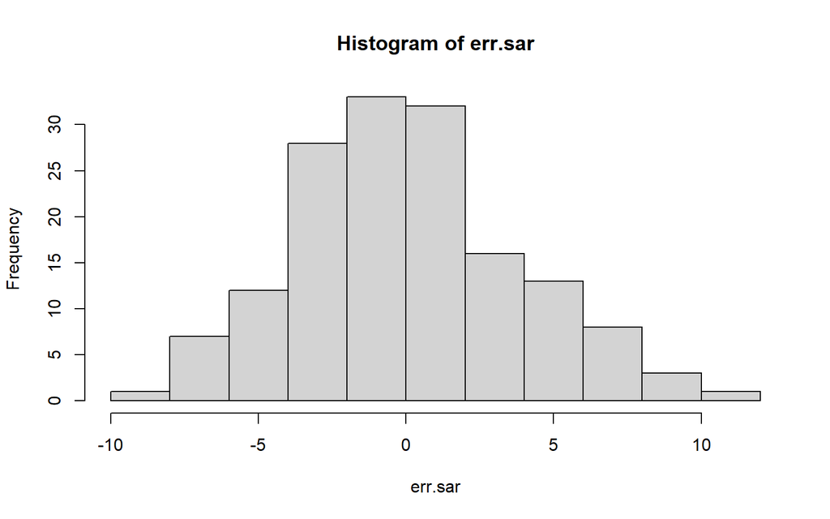

```r
hist(err.sar)
```

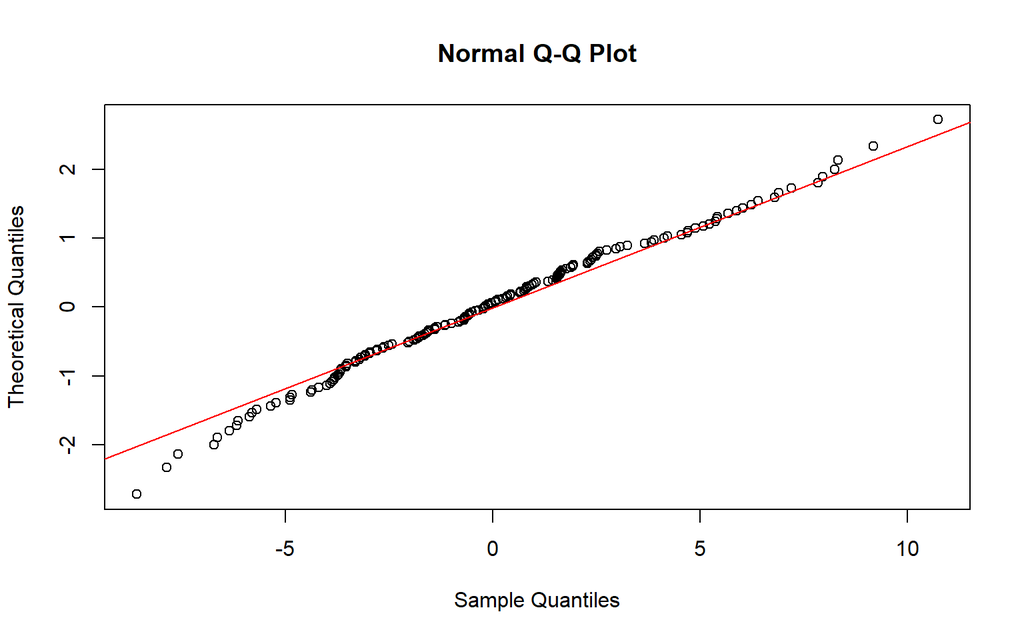

```r
qqnorm(err.sar,datax=T)
qqline(rnorm(length(err.ols),mean(err.ols),sd(err.ols)),datax=T, col="red")
```

#### Asumsi Kehomogenan Ragam

H0 : Ragam Sisaan Homogen

H1 : Ragam Sisaan Tidak Homogen

```r
bptest.Sarlm(sar)
```

```
##
##  studentized Breusch-Pagan test
##
## data:
## BP = 4.4471, df = 5, p-value = 0.487
```

Karena p-value > 5%, maka gagal tolak H0. Artinya ragam sisaan homogen.

#### Uji Kebebasan Sisaan

H0: Tidak ada autokorelasi spasial

H1: ada autokorelasi spasial

```r
moran.test(err.sar, ww, alternative="two.sided")
```

```
##
##  Moran I test under randomisation
##
## data:  err.sar
## weights: ww
##
## Moran I statistic standard deviate = 0.22239, p-value = 0.824
## alternative hypothesis: two.sided
## sample estimates:
## Moran I statistic       Expectation          Variance
##      0.0007093943     -0.0065359477      0.0010614604
```

## Model SEM

```r
sem<-errorsarlm(Y ~ X1 + X2 + X3 + X4 + X5_log, data = data_ipm, listw = ww)
summary(sem,  Nagelkerke = T)
```

```
##
## Call:errorsarlm(formula = Y ~ X1 + X2 + X3 + X4 + X5_log, data = data_ipm,
##     listw = ww)
##
## Residuals:
##      Min       1Q   Median       3Q      Max
## -8.48374 -2.98636 -0.19443  2.27345 10.71635
##
## Type: error
## Coefficients: (asymptotic standard errors)
##              Estimate Std. Error z value  Pr(>|z|)
## (Intercept) 21.931766   2.514166  8.7233 < 2.2e-16
## X1          -1.004718   0.333168 -3.0156  0.002564
## X2           0.068293   0.200799  0.3401  0.733777
## X3           0.062070   0.034764  1.7855  0.074181
## X4          -0.054437   0.024289 -2.2412  0.025015
## X5_log      -1.437894   0.351870 -4.0864 4.381e-05
##
## Lambda: 0.3178, LR test value: 3.3376, p-value: 0.067714
## Asymptotic standard error: 0.15083
##     z-value: 2.107, p-value: 0.035118
## Wald statistic: 4.4394, p-value: 0.035118
##
## Log likelihood: -426.6645 for error model
## ML residual variance (sigma squared): 14.793, (sigma: 3.8462)
## Nagelkerke pseudo-R-squared: 0.25791
## Number of observations: 154
## Number of parameters estimated: 8
## AIC: 869.33, (AIC for lm: 870.67)
```

### Uji Asumsi Model SEM

#### Asumsi Kenormalan Sisaan

H0 : galat model menyebar normal

H1 : galat model tidak menyebar normal

Tolak H0 jika p-value < 0.05

```r
err.sem<-residuals(sem)
ad.test(err.sem)
```

```
##
##  Anderson-Darling normality test
##
## data:  err.sem
## A = 0.4337, p-value = 0.2984
```

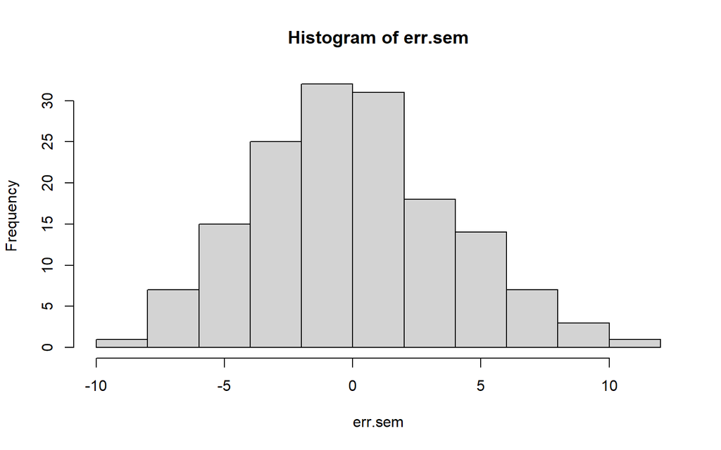

```r
hist(err.sem)
```

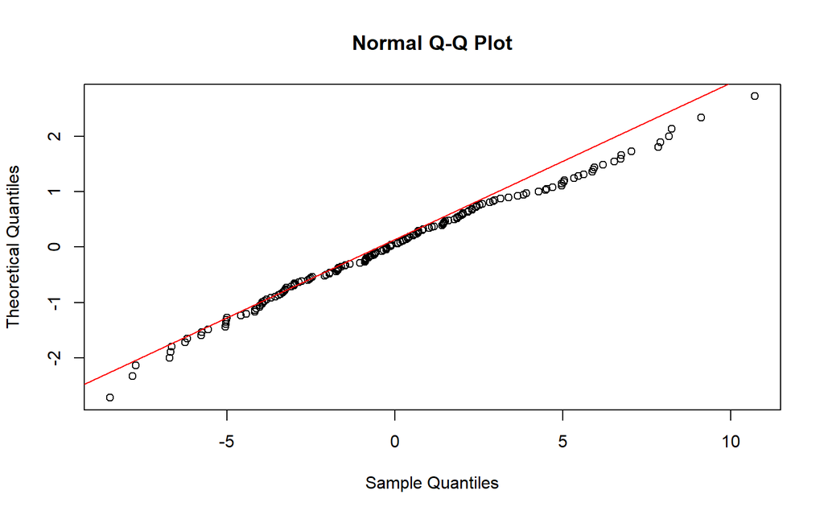

```r
qqnorm(err.sem,datax=T)
qqline(rnorm(length(err.ols),mean(err.ols),sd(err.ols)),datax=T, col="red")
```

#### Asumsi Kehomogenan Ragam

H0 : Ragam Sisaan Homogen

H1 : Ragam Sisaan Tidak Homogen

```r
bptest.Sarlm(sem)
```

```
##
##  studentized Breusch-Pagan test
##
## data:
## BP = 5.1769, df = 5, p-value = 0.3947
```

Karena p-value > 0.05, maka gagal tolak H0. Artinya ragam sisaan homogen.

#### Asumsi Kebesaan Sisaan

H0 : Tidak Ada Autokorelasi spasial

H1 : Ada Autokorelasi spasial

```r
moran.test(err.sem, ww, alternative="two.sided")
```

```
##
##  Moran I test under randomisation
##
## data:  err.sem
## weights: ww
##
## Moran I statistic standard deviate = 0.39867, p-value = 0.6901
## alternative hypothesis: two.sided
## sample estimates:
## Moran I statistic       Expectation          Variance
##       0.006454376      -0.006535948       0.001061727
```

Karena p-value > 0.05 maka gagal Tolak H0 artinya tidak terdapat autokorelasi spasial pada sisaan model SEM.

# Goodness of Fits (Model Terbaik)

```r
df <- data.frame("Model" = c("OLS (Regresi KlasiK)","SAR","SEM"),
           "AIC" = c(AIC(ols),AIC(sar), AIC(sem)))

df
```

```
##                  Model      AIC
## 1 OLS (Regresi KlasiK) 870.6665
## 2                  SAR 868.5501
## 3                  SEM 869.3289
```

Berdasarkan output diatas, model SAR adalah model yang terbaik berdasarkan nilai AIC-nya. Hal ini juga sejalan dengan nilai rho yang signifikan (p-value 0.042). Model SAR ini juga telah memenuhi seluruh asumsi seperti normalitas, kebebasan, dan kehomogenan.

# Interpretasi Model SAR

```r
sum <- summary(sar)
sum
```

```
##
## Call:lagsarlm(formula = Y ~ X1 + X2 + X3 + X4 + X5_log, data = data_ipm,
##     listw = ww)
##
## Residuals:
##      Min       1Q   Median       3Q      Max
## -8.58696 -2.97066 -0.19429  2.33521 10.73820
##
## Type: lag
## Coefficients: (asymptotic standard errors)
##              Estimate Std. Error z value  Pr(>|z|)
## (Intercept) 19.045154   2.862361  6.6537 2.859e-11
## X1          -1.060725   0.336064 -3.1563  0.001598
## X2           0.099839   0.198296  0.5035  0.614623
## X3           0.065360   0.034476  1.8958  0.057985
## X4          -0.054441   0.024165 -2.2528  0.024270
## X5_log      -1.496211   0.349091 -4.2860 1.819e-05
##
## Rho: 0.31412, LR test value: 4.1165, p-value: 0.042468
## Asymptotic standard error: 0.14476
##     z-value: 2.1699, p-value: 0.030014
## Wald statistic: 4.7085, p-value: 0.030014
##
## Log likelihood: -426.275 for lag model
## ML residual variance (sigma squared): 14.722, (sigma: 3.8369)
## Number of observations: 154
## Number of parameters estimated: 8
## AIC: 868.55, (AIC for lm: 870.67)
## LM test for residual autocorrelation
## test value: 0.0043028, p-value: 0.9477
```

peubah yang signifikan yaitu X1,X4, dan X5_log

```r
# Spill over
Im = impacts(sar, listw = ww)
Im
```

```
## Impact measures (lag, exact):
##             Direct    Indirect       Total
## X1     -1.07095554 -0.47555665 -1.54651219
## X2      0.10080227  0.04476114  0.14556341
## X3      0.06599022  0.02930289  0.09529311
## X4     -0.05496564 -0.02440744 -0.07937308
## X5_log -1.51064149 -0.67079872 -2.18144021
```

```r
# Efek Umpan Balik
koef = sum$coefficients[-1]
diref = Im$direct
umbal = diref-koef
cbind.data.frame(Koefisien=koef,EfekLangsung=diref,UmpanBalik=umbal)
```

```
##          Koefisien EfekLangsung    UmpanBalik
## X1     -1.06072522  -1.07095554 -0.0102303171
## X2      0.09983935   0.10080227  0.0009629150
## X3      0.06535985   0.06599022  0.0006303725
## X4     -0.05444058  -0.05496564 -0.0005250600
## X5_log -1.49621106  -1.51064149 -0.0144304230
```

Berikut ini adalah interpretasinya:

**Peubah Penjelas X1**

Pengaruh langsung dari peubah X1 (Rata-rata lama sekolah) adalah sebesar -1.070, artinya Jika rata-rata lama sekolah di wilayah-i meningkat satu satuan, maka rata-rata Y (persentase penduduk miskin) di wilayah tersebut akan menurun sebesar 1.070, jika peubah lainnya tetap.

Pengaruh tidak langsung dari peubah X1 (Rata-rata lama sekolah) bernilai -0.475, artinya Jika rata-rata lama sekolah di wilayah-i meningkat satu satuan, maka rata-rata Y (persentase penduduk miskin) di wilayah tersebut akan menurun sebesar 0.475 persen, jika peubah lainnya tetap.

Pengaruh total dari peubah X1 (Rata-rata lama sekolah) bernilai -1.546, artinya apabila peningkatan rata-rata lama sekolah terjadi di seluruh wilayah maka akan menurunkan persentase penduduk miskin diseluruh wilayah dengan rata-rata peningkatan sebesar 1.546. Efek umpan baliknya sebesar -0.010.

**Peubah Penjelas X4**

Pengaruh langsung dari peubah X4 (rumah tangga dengan akses sanitasi layak) adalah sebesar -0.054, artinya Jika persentase rumah tangga dengan akses sanitasi layak di wilayah-i meningkat satu satuan, maka rata-rata Y (persentase penduduk miskin) di wilayah tersebut akan menurun sebesar 0.054, jika peubah lainnya tetap.

Pengaruh tidak langsung dari peubah X4 (rumah tangga dengan akses sanitasi layak) bernilai -0.024, artinya Jika persentase rumah tangga dengan akses sanitasi layak di wilayah-i meningkat satu satuan, maka rata-rata Y (persentase penduduk miskin) di wilayah tersebut akan menurun sebesar 0.024, jika peubah lainnya tetap.

Pengaruh total dari peubah X4 (rumah tangga dengan akses sanitasi layak) bernilai -0.079, artinya apabila peningkatan persentase rumah tangga dengan akses sanitasi layak terjadi di seluruh wilayah maka akan menurunkan persentase penduduk miskin diseluruh wilayah dengan rata-rata peningkatan sebesar 0.079. Efek umpan baliknya sebesar -0.0005.

**Peubah Penjelas X5_log**

Pengaruh langsung dari peubah log X5 (log PDRB) adalah sebesar -1.510, artinya Jika log PDRB di wilayah-i meningkat satu satuan, maka rata-rata Y (persentase penduduk miskin) di wilayah tersebut akan menurun sebesar 1.510, jika peubah lainnya tetap.

Pengaruh tidak langsung dari peubah log X5 (log PDRB) bernilai -0.6707, artinya Jika log PDRB di wilayah-i meningkat satu satuan, maka rata-rata Y (persentase penduduk miskin) di wilayah tersebut akan menurun sebesar 0.6707, jika peubah lainnya tetap.

Pengaruh total dari peubah log X5 (log PDRB) bernilai -2.181, artinya apabila peningkatan log PDRB terjadi di seluruh wilayah maka akan menurunkan persentase penduduk miskin diseluruh wilayah dengan rata-rata peningkatan sebesar 2.181. Efek umpan baliknya sebesar -0.0144.